# Creating a trail effect for moving objects

What do arrows, swords, ships, and spaceships have in common? Motion! When we want to emphasize movement, we can use trails.

[video not shown]

In this chapter, we’re going to implement what’s commonly called a trail or ribbon effect. This effect has a line that tracks a target position, plots it over time, and connects the points.

To achieve this effect we’re going to:

- Plot a target’s position using resolution settings
- Make the trail independent of its parent’s transform
- Use Godot’s `tool` feature to communicate dependencies in the editor
- Use a Line2D node to connect all the points properly and customize the trail
- Fade the trail using per-point lifetime

We’re also going to use the trail we create in four different use cases to understand its capabilities and limitations.

## Tracking a target

A trail behaves like a particle system. It has an emission point and creates points in space that are connected using a mesh. You can check [Xenko’s ribbons and trails manual](https://doc.xenko.com/latest/jp/manual/particles/ribbons-and-trails.html) to learn more about a standard trail implementation.

Since Godot doesn’t have a built-in implementation for ribbons and trails using particles, we need to simulate them manually. For that, we’ll use a *Line2D*.

Create a new scene and add a *Line2D* node as its root. Name it *Trail2D* and add a script to it.

One of the main issues of using a Line2D by itself is that it doesn’t provide a good emission point. This is because the line it draws is relative to its position, rotation, and scale. We want our trail to ignore these transforms.

To work around the trail’s transforms, we’re going to track a target that can be any 2D node. To allow a default target to be set through the Inspector, we’re going to export a `target_path` variable and try to fetch our target using `get_node(target_path)`.

To make it easier to use our *Trail2D*, if we can’t get the target using the `target_path` variable, we can use its parent as a fallback.

```
class_name Trail2D
extends Line2D

export var target_path: NodePath

onready var target: Node2D = get_node(target_path)


func _ready() -> void:
    if not target:
        target = get_parent() as Node2D
```

By default, our *Trail2D* follows its parent’s transform, which breaks the purpose of tracking the target.

Call `set_as_toplevel(true)` in the `_ready` function to make the trail’s transforms global. When doing so, setting the node’s `position` or `rotation` becomes equivalent to using `global_position` and `global_rotation`.

Let’s make sure our *Trail2D*’s position is `Vector2(0, 0)` to reset any offset we may accidentally add in the editor. Add `position = Vector2.ZERO` at the bottom of the `_ready` callback and clear the line using `clear_points()` to prevent drawing when the game starts.

```
func _ready() -> void:
    # ...
    set_as_toplevel(true)
    position = Vector2.ZERO
    clear_points()
```

## Plotting points

Now that we have a target to track and a line to draw, every frame, we need to add a point at the target’s position. We can do that in the `_process` callback.

Line2D has a method that adds a point to the line: `add_point()`. Let’s use that to add our target’s current position.

Since Line2D draws the line in local space, we need to convert our target’s position using `to_local(global_point: Vector2)`. We’ll use its `global_position` which ignores its local offset.

```
func _process(delta: float) -> void:
    add_point(to_local(target.global_position))
```

We can’t store an infinite amount of points in our trail because we have hardware limitations, and we want the trail to have a limited length. So let’s export a `max_points` variable and set it to `100` by default.

We can use `Line2D.get_point_count()` to check how many points we have in our trail. Let’s remove the oldest point as we add new ones.

```
class_name Trail2D
extends Line2D

export var max_points := 100

# ...

func _process(delta: float) -> void:
    add_point(to_local(target.global_position))
    if get_point_count() > max_points:
        remove_point(0)
```

To prevent drawing additional points, we can check the distance from the last point to the current target position. Then we use a `resolution` variable as a threshold to decide if we should plot this desired point.

Export a new `resolution` variable and create a variable to store the `_last_point` we’ve added. Initially, this is our target’s global position converted to local coordinates.

Now we only plot a point if it’s necessary.

```
class_name Trail2D
extends Line2D

export var resolution := 5.0
# ...

var _last_point := Vector2.ZERO


func _ready() -> void:
# ...

    _last_point = to_local(target.global_position)

func _process(delta: float) -> void:
    var desired_point := to_local(target.global_position)
    var distance := _last_point.distance_to(desired_point)
    if distance > resolution:
        add_point(desired_point)

    if get_point_count() > max_points:
        remove_point(0)
```

## Fading the trail

The trail should fade after some time. To achieve this, we need each point to have its lifetime by storing each point’s creation time in a list.

Let’s create a new array to store this data. We’ll name it `_points_creation_time` and add a `_clock` variable to save the current time in seconds.

Using this, we can compare each point’s creation time to the current time and decide if it should be deleted. To know if a point should be removed, let’s export a `lifetime` variable so we can set this property through the Inspector.

```
export var lifetime := 0.5

var _points_creation_time := []
var _clock := 0.0
```

Let’s update our clock using the `delta` value we get in the `_process` callback.

Since we not only add a point to the trail but also track its creation time, let’s create a method that does that and change our `add_point` call.

We’ll name this method `add_timed_point` and it receives two arguments: the `point` and its creation `time`. Every time we add a new point, we append its creation time to the `_points_creation_time` list.

We also want to remove the first point if our line has more points than its `max_points` variable. Every time we remove a point, we need to remove its time entry from the `_points_creation_time` array. So let’s create a `remove_first_point` method that removes the first point of our line and its time entry.

```
func _process(delta: float) -> void:
    _clock += delta

    # Adding new points if necessary.
    var desired_point := to_local(target.global_position)
    var distance: float = _last_point.distance_to(desired_point)
    if distance > resolution:
        add_timed_point(desired_point, _clock)


func add_timed_point(point: Vector2, time: float) -> void:
    add_point(point)
    _points_creation_time.append(time)
    _last_point = point
    if get_point_count() > max_points:
        remove_first_point()


# Removes the first point in the line and the corresponding time.
func remove_first_point() -> void:
    if get_point_count() > 1:
        remove_point(0)
    _points_creation_time.pop_front()
```

Finally, we’re going to remove every point in the line that is older than our `lifetime`.

Let’s create a `remove_older` method that iterates through the `_points_creation_time` list, checks if the current point is older than `lifetime`, and removes its time entry and the point from the trail.

We can `break` the iteration if the first index doesn’t match this condition because since the points are added in chronological order, the points after are going to be newer.

```
# Remove points older than `lifetime`.
func remove_older() -> void:
    for creation_time in _points_creation_time:
        var delta = _clock - creation_time
        if delta > lifetime:
            remove_first_point()
        # Points in `_points_creation_time` are ordered from oldest to newest so as soon as a point
        # isn't older than `lifetime`, we know all remaining points should stay as well.
        else:
            break
```

Let’s call this method below our `_clock` increment in the `_process` callback.

```
func _process(delta: float) -> void:
    _clock += delta
    remove_older()
...
```

With that, we have our basic trail implementation working. You can test it with a moving object!

Here’s a snippet for a Node2D that moves towards the mouse. Attach it to a Node2D and add our Trail2D as a child of this Node2D.

```
extends Node2D

export var speed := 300.0

var _direction := Vector2.RIGHT

func _process(delta: float) -> void:
    _direction = global_position.direction_to(get_global_mouse_position())
    rotation = _direction.angle()
    translate((_direction * speed) * delta)
```

[video not shown]

## Improving the trail use

We may want to activate the trail effect only in some parts of the game. For instance, with drifting lines, we don’t want the car to always leave tire marks.

Let’s add a variable to control the emission of the trail and let’s call it `is_emitting` and using the `setget` keyword, let’s encapsulate it in a `set_emitting` method. Inside this method, we are going to receive a new value and assign it to the `is_emitting` variable. Since we can call this method before we get our `target` node, we need to yield for the “ready” signal. Doing so ensures that we don’t run into errors when we just add a new trail in our game.

After that, we clear the points, and their creation time to generate an entirely new trail from the point we start emitting again. For that, we are also going to update the `_last_point` to this new emitting point.

```
export var is_emitting := false setget set_emitting

# ...

func set_emitting(emitting: bool) -> void:
    is_emitting = emitting

    if not is_inside_tree():
        yield(self, "ready")

    if is_emitting:
        clear_points()
        _points_creation_time.clear()
        _last_point = to_local(target.global_position)
```

Now it’s time to make our trail usable by our teammates and our future self.

First of all, we need to communicate that our trail effect has a dependency, it needs a target to track, and this target needs a position to be tracked, in other words, it needs to inherit from Node2D.

To implement this feature, we need to turn our trail script in a tool script by adding the `tool` keyword at the top of the file. The tool mode makes the code run in the editor, which is dangerous. In `_ready()`, after getting the target node, we should turn off the `_process()` callback if we are in the editor.

```
func _ready() -> void:
    if not target:
        target = get_parent() as Node2D

    # Disables the trail's behavior in the Editor
    if Engine.editor_hint:
        set_process(false)
        return
```

We do the same thing in the `set_emitting` method after assigning the value to the `is_emitting` variable to prevent the `clear_points()` call to clear points in the editor.

```
func set_emitting(emitting: bool) -> void:
        is_emitting = emitting

        if Engine.editor_hint:
                return

        # ...
```

```
func _get_configuration_warning() -> String:
    var warning := "Missing Target node: assign a Node that extends Node2D in the Target Path or make the trail a child of a parent that extends Node2D"
    if target:
        warning = ""
    return warning
```

To prevent logging an error in the output console every time the `get_node` method fails, let’s change the `onready var target = get_node(target_path)` line to `onready var target = get_node_or_null(target_path)`.

It’s common to move the trail a bit away from the target’s actual position. For instance, in our demo scene, it is at the bottom of the spaceship instead of its center. To maintain this offset we are going to add an `_offset` to the plotted points and add a rotation offset if the user rotates the trail.

```
func calculate_offset() -> Vector2:
  return -polar2cartesian(1.0, target.rotation) * _offset
```

Remember, since we are using `set_as_toplevel(true)` the original transform of the trail gets ignored after the game starts, so before we call this method, we need to store the initial offset in the `_offset` variable.

When we add a new point, and when we first set the `_last_point` variable, we should add this offset: in the `_ready`, `set_emitting`, and `add_timed_point` methods.

```
func _ready() -> void:
        ...
    _offset = position.length()
    clear_points()
    set_as_toplevel(true)
    position = Vector2.ZERO
    _last_point = to_local(target.global_position) + calculate_offset()


func add_timed_point(point: Vector2, time: float) -> void:
    add_point(point + calculate_offset())
    # ...


func set_emitting(emitting: bool) -> void:
    # ...
    if is_emitting:
        clear_points()
        _points_creation_time.clear()
        _last_point = to_local(target.global_position) + calculate_offset()
```

## Using the trail

Now that we have our effect in place, let’s look at some common use cases.

### Flying arrows

[video not shown]

We want the trail to match the arrow’s motion, providing visual feedback to help players track its movement. For that, let’s add our trail at the arrow’s back, the fletching.

Now let’s match the trail’s width to the arrow’s. We are going to design a stylized movement trail; one technique commonly used is to narrow the trail as the target moves. To achieve that, in the trail’s *Width Curve*, create a new curve, and make a line like the one below.

This chart represents the width in the vertical axis and the point in the horizontal axis, in our case we want the last point to be wider than the first one. They represent, respectively, the older and newest points of our trail.

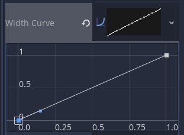

This chart represents the vertical axis’s width and the point in the horizontal axis; in our case, we want the line to be thicker when it’s closer to the last point.

To smooth the fading of our trail, let’s make the older points get more transparent. In *Fill > Gradient*, pick the color that best represents your arrow and add it at the beginning and end of the Gradient, make sure to make the color on the left, that represents the oldest point, full transparent while the rightmost one completely opaque.

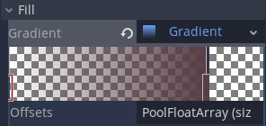

### Melee weapons

[video not shown]

You can use the same approach as the Flying Arrows. But instead of tracking the sword directly, we track a point in the middle of it. We then need to adjust the trail *Width* to match the part that we want to track, such as the blade.

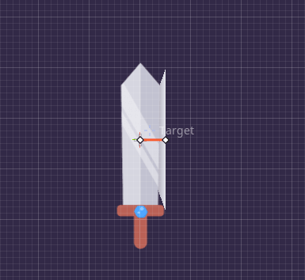